# Практическое занятие 3: Transitivy and clustering

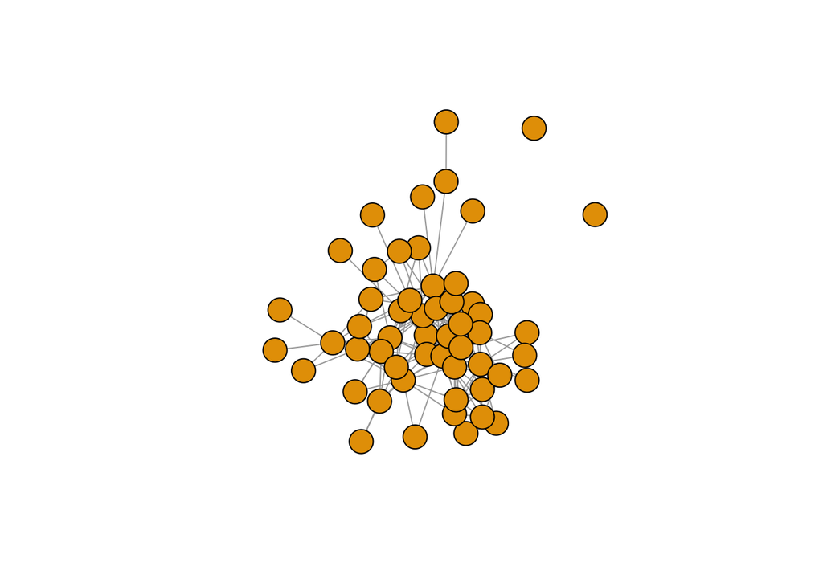

# Transitivity

types of transitivity in R

list(“global”) The global transitivity of an undirected graph (directed graphs are considered as undirected ones as well). This is simply the ratio of the triangles and the connected triples in the graph. For directed graph the direction of the edges is ignored.

list(“local”) The local transitivity of an undirected graph, this is calculated for each vertex given in the vids argument. The local transitivity of a vertex is the ratio of the triangles connected to the vertex and the triples centered on the vertex. For directed graph the direction of the edges is ignored.

list(“undirected”) This is the same as global.

list(“globalundirected”) This is the same as global.

list(“localundirected”) This is the same as local.

list(“barrat”) The weighted transitivity as defined A. Barrat. See details below.

list(“weighted”) The same as barrat.

### Global transitivity

```
## [1] 0.2974504
```

### Local transitivity

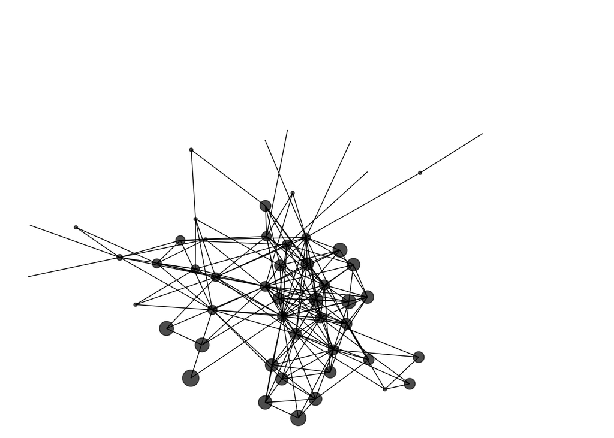

Undirected type of transitivity

```
## [1] 0.2974504
```

Barrat transitivity

```
##  [1] 0.15833333 0.47222222 0.33333333 0.19696970 0.16363636 0.14285714
##  [7] 0.24183007 0.66666667 0.22222222 0.22222222 0.37878788 0.25296443
## [13] 0.33333333 0.50000000 0.00000000 0.00000000        NaN 0.66666667
## [19] 0.19047619 0.03571429 0.27472527 0.26666667 0.32727273 0.33333333
## [25] 0.31666667 0.33333333 0.52380952 0.25714286 0.60000000        NaN
## [31] 0.40000000 0.30000000 0.60000000 0.83333333 0.47619048 0.53571429
## [37] 0.52380952        NaN        NaN        NaN 0.20000000        NaN
## [43] 0.00000000 1.00000000        NaN 0.00000000 0.66666667 0.66666667
## [49] 0.00000000 0.00000000 0.00000000 0.00000000        NaN        NaN
```

# Clustering coefficient

Global clustering coefficient

```
## [1] 0.2706296
```

Local clustering coefficient

```
##    X1    X2    X3    X4    X5    X6    X7    X8    X9   X10   X11   X12
## 0.158 0.472 0.333 0.197 0.164 0.143 0.242 0.667 0.222 0.222 0.379 0.253
##   X13   X14   X15   X16   X17   X18   X19   X20   X21   X22   X23   X24
## 0.333 0.500 0.000 0.000 0.000 0.667 0.190 0.036 0.275 0.267 0.327 0.333
##   X25   X26   X27   X28   X29   X30   X31   X32   X33   X34   X35   X36
## 0.317 0.333 0.524 0.257 0.600 0.000 0.400 0.300 0.600 0.833 0.476 0.536
##   X37   X38   X39   X40   X41   X42   X43   X44   X45   X46   X47   X48
## 0.524 0.000 0.000 0.000 0.200 0.000 0.000 1.000 0.000 0.000 0.667 0.667
##   X49   X50   X51   X52   X53   X54
## 0.000 0.000 0.000 0.000 0.000 0.000
```

# Community detection algorithms

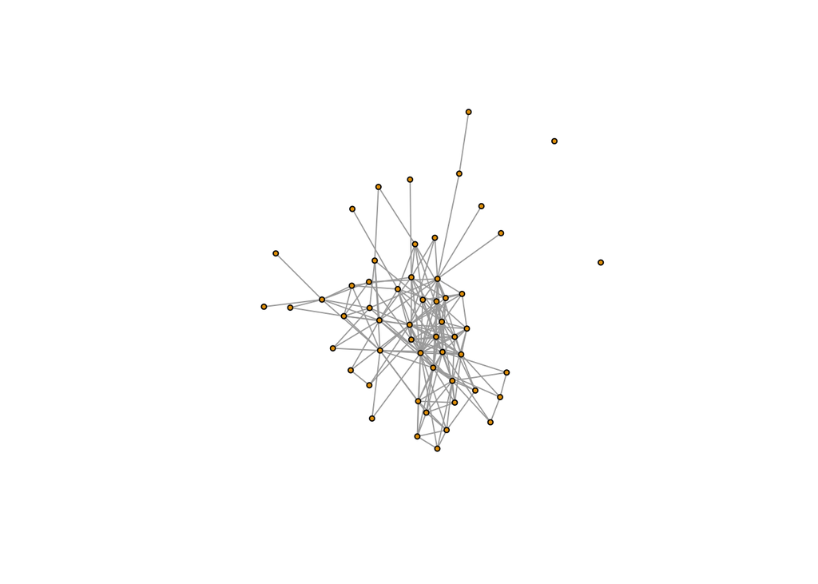

## Cliques

Размер клик

```
##   [1] 3 3 3 3 3 3 3 3 3 3 3 3 3 3 3 3 3 3 3 3 3 3 3 3 3 3 3 3 3 3 3 3 3 3 3
##  [36] 4 3 4 3 3 3 4 3 4 3 3 3 3 4 3 3 3 3 3 4 3 3 3 3 3 4 3 3 3 3 3 3 3 3 4
##  [71] 3 4 3 3 4 3 3 3 3 4 3 4 3 3 3 3 4 4 5 4 5 4 3 3 4 3 4 3 3 4 3 3 4 3 4
## [106] 3 3 3 4 3 4 3 3 4 3 3 4 3 4 3 3 3 3 3 4 4 3 3 3 4 3 4 3 3 4 3 4 4 4 3
## [141] 3 3 3 3 3 3 3 4 3 3 3 3 3 4 4 3 3 3 3 3 3 3 4 4 5 4 3 3 4 3 3 3 4 3 3
## [176] 3 3 3 3 3 4 3 4 3 3 3 3 3 4 3 4 3 3 4 4 3 3 3 3 4 4 3 4 3 4 3 3 3 3 3
## [211] 3 3 3 4 5 6 5 4 5 4 3 4 5 4 3 4 3 4 3 3 4 5 4 3 4 5 4 3 4 3 3 4 3 3 3
## [246] 4 3 3 3 3 3
```

Самые большие клики

```
## [[1]]
## + 6/54 vertices, named, from c9849ad:
## [1] X12 X7  X8  X23 X11 X29
```

Визуализация клик

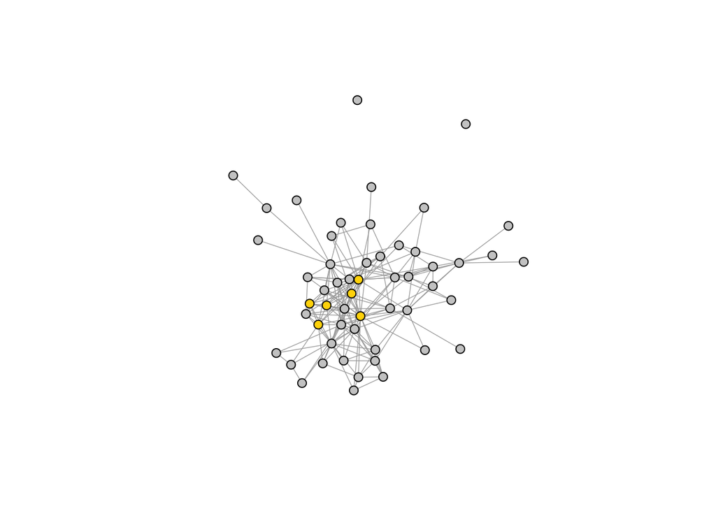

## K-cores

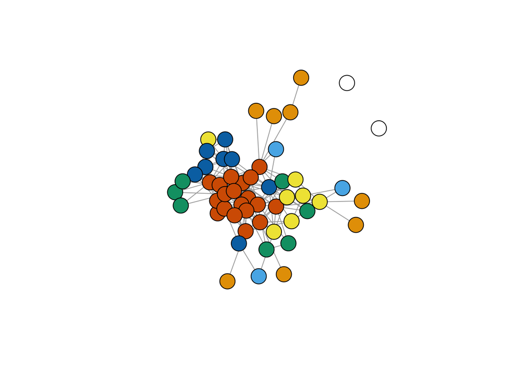

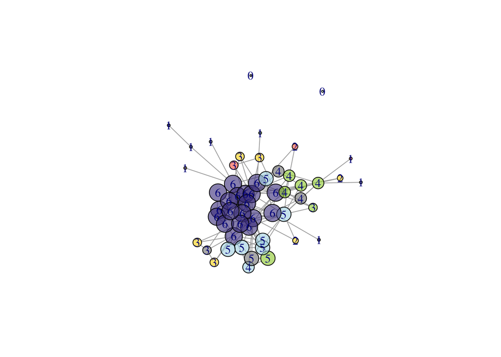

## Louvaine

```
## Community sizes
##  1  2  3  4  5  6  7
## 10  8  7  1  1 15 12
```

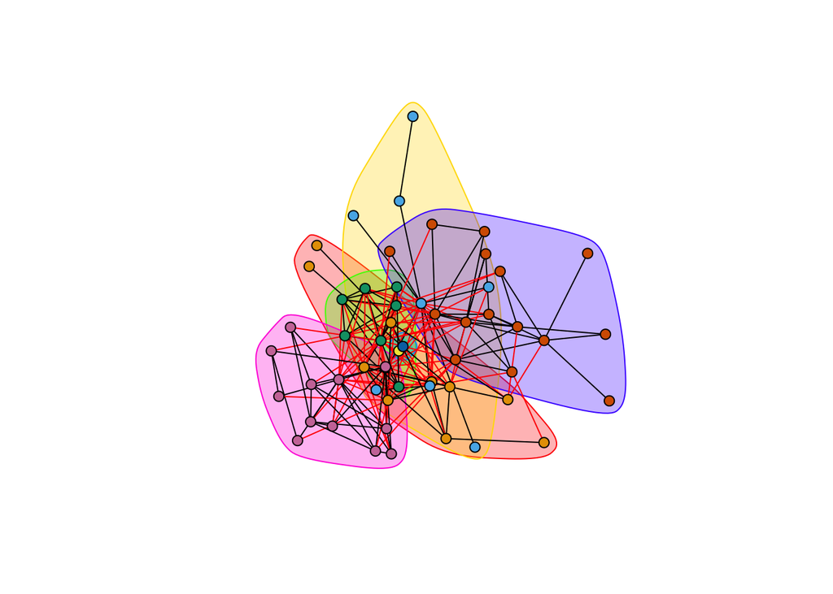

# Articulation points

```
## + 5/54 vertices, named, from c9849ad:
## [1] X20 X10 X9  X43 X1
```

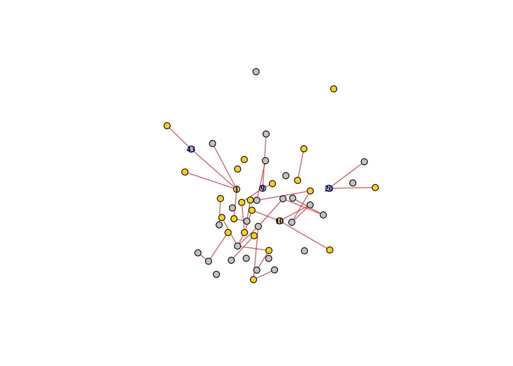

# Bi components

```
##                     Length Class     Mode
## no                  1      -none-    numeric
## tree_edges          9      -none-    list
## component_edges     9      -none-    list
## components          9      -none-    list
## articulation_points 5      igraph.vs numeric
```

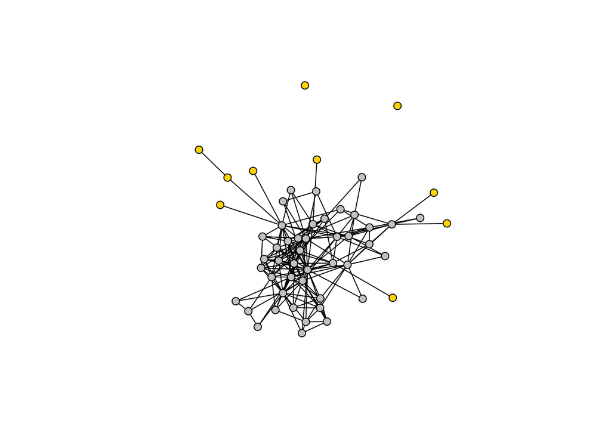